# STATS 506 - Homework 4

Author

Vincent Weng

### Problem 1 - Tidyverse

Use the tidyverse for this problem. In particular, use piping and dplyr as much as you are able. Note: Use of any deprecated functions will result in a point loss.

Install and load the package nycflights13.

```r
library(tidyverse) # using tidyverse
```

Part (A) - Generate a table (which can just be a nicely printed tibble) reporting the mean and median departure delay per airport. Generate a second table (which again can be a nicely printed tibble) reporting the mean and median arrival delay per airport. Exclude any destination with under 10 flights. Do this exclusion through code, not manually.

Additionally,

Order both tables in descending mean delay. Both tables should use the airport names not the airport codes. Both tables should print all rows.

```r
library(nycflights13)

# tidyverse pipeline for departure
flights %>%
  group_by(origin) %>%
  summarize(mean_delay = mean(dep_delay, na.rm = TRUE),
            median_delay = median(dep_delay, na.rm = TRUE),
            total_flights = n()) %>%
  ungroup() %>%
  filter(total_flights >= 10) %>%
  rename(faa = origin) %>%
  left_join(airports, by = "faa") %>%
  select(name, mean_delay, median_delay) %>%
  arrange(desc(mean_delay))
```

```
# A tibble: 3 × 3
  name                mean_delay median_delay
  <chr>                    <dbl>        <dbl>
1 Newark Liberty Intl       15.1           -1
2 John F Kennedy Intl       12.1           -1
3 La Guardia                10.3           -3
```

```r
# tidyverse pipeline for arrival
flights %>%
  group_by(dest) %>%
  summarize(mean_delay = mean(arr_delay, na.rm = TRUE),
            median_delay = median(arr_delay, na.rm = TRUE),
            total_flights = n()) %>%
  ungroup() %>%
  filter(total_flights >= 10) %>%
  rename(faa = dest) %>%
  left_join(airports, by = "faa") %>%
  select(name, mean_delay, median_delay) %>%
  arrange(desc(mean_delay)) %>%
  print(n=count(.))
```

```
# A tibble: 102 × 3
    name                                   mean_delay median_delay
    <chr>                                       <dbl>        <dbl>
  1 "Columbia Metropolitan"                   41.8            28
  2 "Tulsa Intl"                              33.7            14
  3 "Will Rogers World"                       30.6            16
  4 "Jackson Hole Airport"                    28.1            15
  5 "Mc Ghee Tyson"                           24.1             2
  6 "Dane Co Rgnl Truax Fld"                  20.2             1
  7 "Richmond Intl"                           20.1             1
  8 "Akron Canton Regional Airport"           19.7             3
  9 "Des Moines Intl"                         19.0             0
 10 "Gerald R Ford Intl"                      18.2             1
 11 "Birmingham Intl"                         16.9            -2
 12 "Theodore Francis Green State"            16.2             1
```

[output cut: 90 more lines]

Part (B) - How many flights did the aircraft model with the fastest average speed take? Produce a tibble with 1 row, and entries for the model, average speed (in MPH) and number of flights.

```r
flights %>%
  left_join(planes, by="tailnum") %>%
  # calculate mph (distance per hour of flight)
  mutate(mph = distance / (air_time / 60)) %>%
  group_by(model) %>%
  # calculate average mph and total number of flights
  summarize(avg_mph = mean(mph, na.rm = TRUE), num_flights = n()) %>%
  arrange(desc(avg_mph)) %>%
  slice(1)
```

```
# A tibble: 1 × 3
  model   avg_mph num_flights
  <chr>     <dbl>       <int>
1 777-222    483.           4
```

### Problem 2 - get_temp()

```r
#' Computes monthly average temperature
#' @param month Integer or string. Month as a number (1-12), name, or abbrev.
#' @param year Integer. Year (between 1997 and 2000).
#' @param data Data frame with columns temp, month_numeric, and year.
#' @param celsius Logical. Default is 'FALSE'.
#' @param average_fn Function for average temp. Default is 'mean'.
#' @return Numeric. Average temperature.
get_temp <- function(month, year, data, celsius = FALSE, average_fn = mean) {

  # check numeric and string months
  if (is.numeric(month)) {
    # check month is valid
    if (month < 1 || month > 12) {
      stop("Invalid month: Numeric months must be between 1 and 12")
    }
  } else if (is.character(month)) {
    # check string is valid month or abbrev
    valid_months <- c("January", "February", "March", "April", "May", "June",
                      "July", "August", "September", "October", "November", "December")
    abbrev_months <- substr(valid_months, 1, 3)  # get abbrev

    if (month %in% abbrev_months) {
      # if month is abbrev, find full month name
      month <- valid_months[which(abbrev_months == month)]
    } else if (!(month %in% valid_months)) {
      stop("Invalid month: Must be a valid month name or abbreviation")
    }

    # convert month to numeric
    month <- match(month, valid_months)
  } else {
    stop("Invalid month: Must be either numeric or a string")
  }

  # check year is numeric
  if (!is.numeric(year)) {
    stop("Invalid year: Must be numeric")
  }

  if (year > 2000 || year < 1997) {
    stop("Invalid year: Year is out of range")
  }

  # check average_fn is a function
  if (!is.function(average_fn)) {
    stop("Invalid average_fn: Must be a function")
  }

  # filter data and calculate the temp
  result <- data %>%
    select(temp, month_numeric, year) %>%
    rename(year_col = year) %>%
    filter(year_col == year, month_numeric == month) %>%
    summarize(average_temp = average_fn(temp)) %>%
    mutate(
      avg_temp_celsius = (average_temp - 32) * 5 / 9,
      final_avg_temp = if (isTRUE(celsius)) avg_temp_celsius else average_temp
    ) %>%
    pull(final_avg_temp)  # pull result as a numeric value

  return(result)
}


nnmaps <- read_csv("chicago-nmmaps.csv")
```

```r
get_temp("Apr", 1999, data = nnmaps)
```

```
[1] 49.8
```

```r
get_temp("Apr", 1999, data = nnmaps, celsius = TRUE)
```

```
[1] 9.888889
```

```r
get_temp(10, 1998, data = nnmaps, average_fn = median)
```

```
[1] 55
```

```r
tryCatch({
  get_temp(13, 1998, data = nnmaps)
}, error = function(e) {
  cat("Error: ", e$message, "\n")
})
```

```
Error:  Invalid month: Numeric months must be between 1 and 12
```

```r
tryCatch({
  get_temp(2, 2005, data = nnmaps)
}, error = function(e) {
  cat("Error: ", e$message, "\n")
})
```

```
Error:  Invalid year: Year is out of range
```

```r
get_temp("November", 1999, data =nnmaps, celsius = TRUE,
         average_fn = function(x) {
           x %>% sort -> x
           x[2:(length(x) - 1)] %>% mean %>% return
         })
```

```
[1] 7.301587
```

### Problem 3 - Visualization

Note: This is, intentionally, a very open-ended question. There is no “right” answer. The goal is for you to explore your plotting options, and settle on something reasonable. You can use base R, ggplot, or something else. You’ll likely have to look online for resources on plotting beyond what we covered in class.

This dataset lists characteristics of art sales. Download the file named “df_for_ml_improved_new_market” (NOT the “df_for_ml_improved_new_market_1” version!). For each of the following, produce a publication-ready plot which demonstrates the answer to the question. Use your plot to support an argument for your question.

Part (A) - Is there a change in the sales price in USD over time?

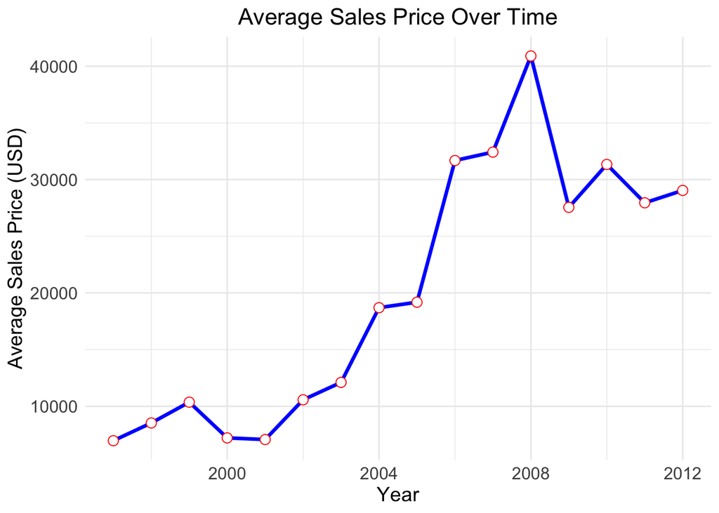

```r
library(ggplot2)
df <- read.csv("df_for_ml_improved_new_market.csv")

# calculate the average price_usd for each year
average_price_by_year <- df %>%
  group_by(year) %>%
  summarize(avg_price = mean(price_usd, na.rm = TRUE))

# plot the average price_usd over time
ggplot(average_price_by_year, aes(x = year, y = avg_price)) +
  geom_line(size = 1.2, color = "blue") + # thicker line and custom color
  geom_point(size = 3, color = "red", shape = 21, fill = "white") +  # larger points with a custom fill
  labs(title = "Average Sales Price Over Time",
       x = "Year",
       y = "Average Sales Price (USD)") +
  theme_minimal() + #. cleaner minimal theme
  theme(
    plot.title = element_text(hjust = 0.5, size = 16),  # center title and adjust font size
    axis.title.x = element_text(size = 14),
    axis.title.y = element_text(size = 14),
    axis.text = element_text(size = 12)  # adjust axis text size
  )
```

Part (B) - Does the distribution of genre of sales across years appear to change?

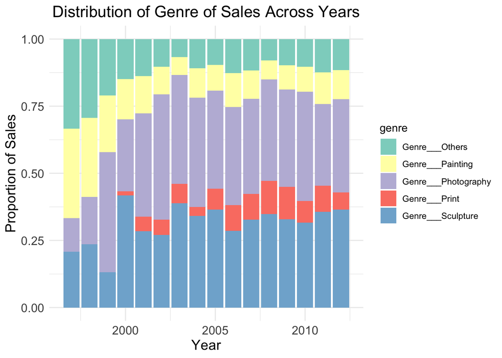

```r
df_long <- df %>%
  pivot_longer(cols = starts_with("Genre___"),
               names_to = "genre",
               values_to = "count") %>%
  filter(count == 1)  # assuming binary encoding (1 if sale in that genre, else 0)

# create stacked bar chart
ggplot(df_long, aes(x = year, fill = genre)) +
  geom_bar(position = "fill") +  # position fill for proportion stacking
  labs(title = "Distribution of Genre of Sales Across Years",
       x = "Year",
       y = "Proportion of Sales") +
  scale_fill_brewer(palette = "Set3") +
  theme_minimal() +
  theme(
    plot.title = element_text(hjust = 0.5, size = 16),
    axis.title.x = element_text(size = 14),
    axis.title.y = element_text(size = 14),
    axis.text = element_text(size = 12)
  )
```

Part (C) - How does the genre affect the change in sales price over time?

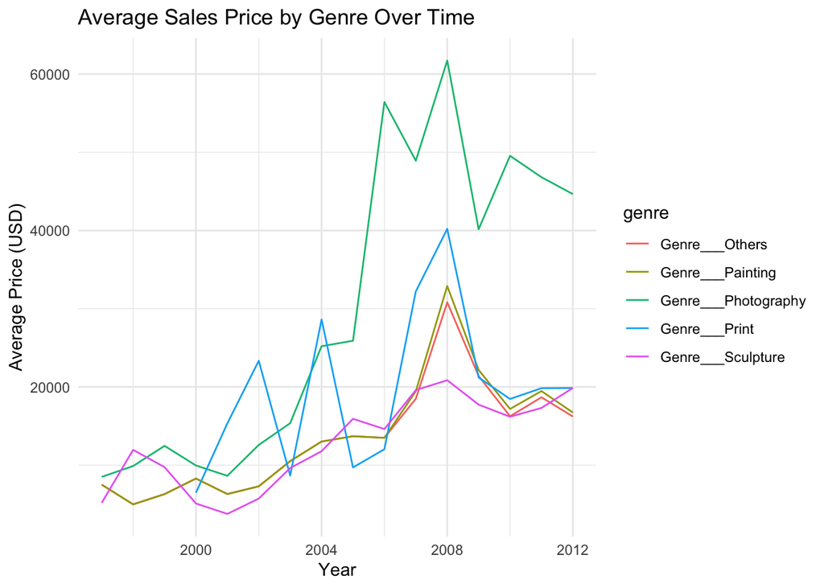

```r
df_long_genre_price <- df %>%
  pivot_longer(
    cols = starts_with("Genre___"),  # select columns starting with "Genre___"
    names_to = "genre",              # create new column named "genre"
    values_to = "count"              # store orig val in new column "count"
  ) %>%

  filter(count == 1) %>% # filter where count is 1 (presence of that genre)

  # group the data by year and genre to calculate average price in each group
  group_by(year, genre) %>%
  summarize(
    avg_price = mean(price_usd, na.rm = TRUE)  # calculate average prices
  ) %>%

  ungroup() # remove the grouping to return to a regular df
# create line plot to visualize average price over time
ggplot(df_long_genre_price, aes(x = year, y = avg_price, color = genre)) +
  geom_line() +  # Plot lines for each genre showing avg_price over time
  labs(
    title = "Average Sales Price by Genre Over Time",
    x = "Year",
    y = "Average Price (USD)"
  ) +
  theme_minimal()  # apply a minimal theme
```